# The Tidyverse and Data Wrangling

Brandon Le

# About the Core

## IIGB Bioinformatics Core

- Website
- Services
- Workshops
- Office Hour

https://facility.bioinformatics.ucr.edu

[figure not shown]

- Data analysis
  - RNA-seq, ChIP-seq
  - scRNA-seq
  - DNA-seq
  - Other
- Project consultations
- Method development
- [Repositories](https://github.com/orgs/bioinformatics-workshop/repositories)
- Past workshops
  - [Intro to Unix](https://github.com/bioinformatics-workshop/Intro-to-Unix)
  - [Intro to R/R-Studio](https://github.com/bioinformatics-workshop/Intro-to-R-RStudio)
  - [Intro to Shell Scripting](https://github.com/bioinformatics-workshop/Intro-to-Shell-Scripting)
  - [RNA-seq-workshop](https://github.com/bioinformatics-workshop/RNA-Seq-Workshop)
- Daily (2-3PM)
- In-person or via Zoom (by appt)
- [Zoom Scheduler](https://scheduler.zoom.us/iigb-bioinfo-core)

# OnDemand

## Logging in to the server via OnDemand

You should receive an email with login information if you’ve never had an account on the HPCC. For those with an account already, you can use the same credentials to log into the server.

Open up your browser and type the following URL: https://ondemand.hpcc.ucr.edu

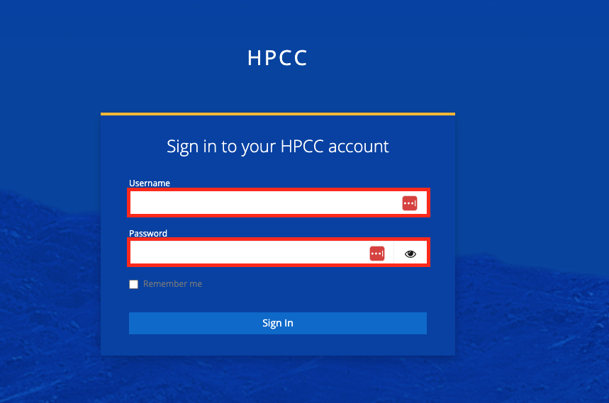

**Note**

Use the provided login credentials to log in to OnDemand. Then you’ll be ask for authentication password and two-factor validation with DUO.

After logging in, you’ll see the HPCC OnDemand Welcome Page

[figure not shown]

## Requesting an Interactive Session

To request an interactive app, click on `Interactive Apps` and select the App of interest (e.g. RStudio Server).

[figure not shown]

You will see an app launch form. Fill in the following information:

[figure not shown]

Then click `Launch` and wait for resources to be gathered for your app.

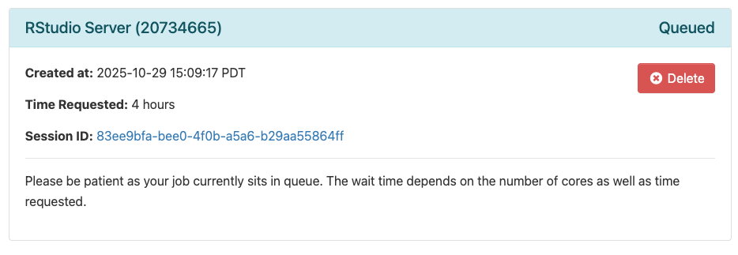

Once the app is ready, click `Connect to RStudio` to launch the RStudio Server.

[figure not shown]

## RStudio

[figure not shown]

## Lets Get Started

Go to the GitHub repository https://github.com/bioinformatics-workshop

Select the workshop Intro-to-Tidyverse-2026

Click on the `<> Code` button and copy the HTTPS URL

In the terminal tab in Rstudio (in the console section), type in `git clone` and paste the URL from github (see below)

`git clone https://github.com/bioinformatics-workshop/Intro-to-Tidyverse-2026.git`

Now, you should have a clone of the workshop documents with scripts and html files to follow.